# EasyVisa_Project

### VISA APPROVAL PREDICTIONS

## Bussiness Context

Business communities in the United States are facing high demand for human resources, but one of the constant challenges is identifying and attracting the right talent, which is perhaps the most important element in remaining competitive. Companies in the United States look for hard-working, talented, and qualified individuals both locally as well as abroad.

The Immigration and Nationality Act (INA) of the US permits foreign workers to come to the United States to work on either a temporary or permanent basis. The act also protects US workers against adverse impacts on their wages or working conditions by ensuring US employers' compliance with statutory requirements when they hire foreign workers to fill workforce shortages. The immigration programs are administered by the Office of Foreign Labor Certification (OFLC).

OFLC processes job certification applications for employers seeking to bring foreign workers into the United States and grants certifications in those cases where employers can demonstrate that there are not sufficient US workers available to perform the work at wages that meet or exceed the wage paid for the occupation in the area of intended employment.

## Objective

In FY 2016, the OFLC processed 775,979 employer applications for 1,699,957 positions for temporary and permanent labor certifications. This was a nine percent increase in the overall number of processed applications from the previous year. The process of reviewing every case is becoming a tedious task as the number of applicants is increasing every year.

The increasing number of applicants every year calls for a Machine Learning based solution that can help in shortlisting the candidates having higher chances of VISA approval. OFLC has hired the firm EasyVisa for data-driven solutions. You as a data scientist at EasyVisa have to analyze the data provided and, with the help of a classification model:

1. Facilitate the process of visa approvals.
2. Recommend a suitable profile for the applicants for whom the visa should be certified or denied based on the drivers that significantly influence the case status.

## Data Description

The data contains the different attributes of the employee and the employer. The detailed data dictionary is given below.

**case_id:** ID of each visa application

**continent:** Information of continent the employee

**education_of_employee:** Information of education of the employee

**has_job_experience:** Does the employee has any job experience? Y = Yes; N = No

**requires_job_training:** Does the employee require any job training? Y = Yes; N = No

**no_of_employees:** Number of employees in the employer’s company

**yr_of_estab:** Year in which the employer’s company was established

**region_of_employment:** Information of foreign workers and region of employment in the US

**prevailing_wage:** Average wage paid to similarly employed workers in a specific occupation in the area of intended employment.

**unit_of_wage:** Unit of prevailing wage. Values include Hourly, Weekly, Monthly, and Yearly.

**full_time_position:** Is the position of work full-time? Y = Full-Time Position; N = Part-Time Position

**case_status:** Flag indicating if the Visa was certified or denied

### What is prevailing_wage

**prevailing_wage:** Average wage paid to similarly employed workers in a specific occupation in the area of intended employment. The purpose of the prevailing wage is to ensure that the foreign worker is not underpaid compared to other workers offering the same or similar service in the area of employment.

### Importing necessary libraries

```python
# Libraries to help with reading and manipulating data
import pandas as pd
import numpy as np

# Libaries to help with data visualization
import matplotlib.pyplot as plt
import seaborn as sns

# To tune model, get different metric scores, and split data
from sklearn.metrics import (
    f1_score,
    accuracy_score,
    recall_score,
    precision_score,
    confusion_matrix,
    roc_auc_score,
    ConfusionMatrixDisplay,
)
from sklearn.model_selection import train_test_split, StratifiedKFold, cross_val_score

# To be used for data scaling and one hot encoding
from sklearn.preprocessing import StandardScaler, MinMaxScaler, OneHotEncoder, LabelEncoder

# To impute missing values
from sklearn.impute import SimpleImputer
from sklearn import metrics

# To oversample and undersample data
from imblearn.over_sampling import SMOTE
from imblearn.under_sampling import RandomUnderSampler

# To do hyperparameter tuning
from sklearn.model_selection import RandomizedSearchCV

# To define maximum number of columns to be displayed in a dataframe
pd.set_option("display.max_columns", None)

# To supress scientific notations for a dataframe
pd.set_option("display.float_format", lambda x: "%.3f" % x)

# To help with model building
from sklearn.tree import DecisionTreeClassifier
from sklearn.ensemble import (
    AdaBoostClassifier,
    GradientBoostingClassifier,
    RandomForestClassifier,
    BaggingClassifier,
)
from xgboost import XGBClassifier
from sklearn.linear_model import LogisticRegression

# To suppress scientific notations
pd.set_option("display.float_format", lambda x: "%.3f" % x)

# To supress warnings
import warnings

warnings.filterwarnings("ignore")
```

### Loading the Data

```python
# Write your code here to read the data
from google.colab import drive
drive.mount('/content/drive')

data = pd.read_csv('/content/drive/My Drive/EasyVisa.csv')
```

```python
#Verify the shape of data
data.shape
```

```
(25480, 12)
```

- There are 25480 rows and 12 columns

## Data Overview

```python
# Create a copy of data
df = data.copy()
```

### Displaying the first few rows and Last few rows

```python
# Display first few rows
df.head()
```

|  | case_id | continent | education_of_employee | has_job_experience | requires_job_training | no_of_employees | yr_of_estab | region_of_employment | prevailing_wage | unit_of_wage | full_time_position | case_status |
| --- | --- | --- | --- | --- | --- | --- | --- | --- | --- | --- | --- | --- |
| 0 | EZYV01 | Asia | High School | N | N | 14513 | 2007 | West | 592.203 | Hour | Y | Denied |
| 1 | EZYV02 | Asia | Master's | Y | N | 2412 | 2002 | Northeast | 83425.650 | Year | Y | Certified |
| 2 | EZYV03 | Asia | Bachelor's | N | Y | 44444 | 2008 | West | 122996.860 | Year | Y | Denied |
| 3 | EZYV04 | Asia | Bachelor's | N | N | 98 | 1897 | West | 83434.030 | Year | Y | Denied |
| 4 | EZYV05 | Africa | Master's | Y | N | 1082 | 2005 | South | 149907.390 | Year | Y | Certified |

```python
# Display last few rows
df.tail()
```

|  | case_id | continent | education_of_employee | has_job_experience | requires_job_training | no_of_employees | yr_of_estab | region_of_employment | prevailing_wage | unit_of_wage | full_time_position | case_status |
| --- | --- | --- | --- | --- | --- | --- | --- | --- | --- | --- | --- | --- |
| 25475 | EZYV25476 | Asia | Bachelor's | Y | Y | 2601 | 2008 | South | 77092.570 | Year | Y | Certified |
| 25476 | EZYV25477 | Asia | High School | Y | N | 3274 | 2006 | Northeast | 279174.790 | Year | Y | Certified |
| 25477 | EZYV25478 | Asia | Master's | Y | N | 1121 | 1910 | South | 146298.850 | Year | N | Certified |
| 25478 | EZYV25479 | Asia | Master's | Y | Y | 1918 | 1887 | West | 86154.770 | Year | Y | Certified |
| 25479 | EZYV25480 | Asia | Bachelor's | Y | N | 3195 | 1960 | Midwest | 70876.910 | Year | Y | Certified |

### Checking the datatypes of data

```python
#check for datatypes
df.info()
```

```
<class 'pandas.core.frame.DataFrame'>
RangeIndex: 25480 entries, 0 to 25479
Data columns (total 12 columns):
 #   Column                 Non-Null Count  Dtype
---  ------                 --------------  -----
 0   case_id                25480 non-null  object
 1   continent              25480 non-null  object
 2   education_of_employee  25480 non-null  object
 3   has_job_experience     25480 non-null  object
 4   requires_job_training  25480 non-null  object
 5   no_of_employees        25480 non-null  int64
 6   yr_of_estab            25480 non-null  int64
 7   region_of_employment   25480 non-null  object
 8   prevailing_wage        25480 non-null  float64
 9   unit_of_wage           25480 non-null  object
 10  full_time_position     25480 non-null  object
 11  case_status            25480 non-null  object
dtypes: float64(1), int64(2), object(9)
memory usage: 2.3+ MB
```

- There are 9 object type features
- There are 2 integer type features and 1 float type feature

### Check for missing values

```python
### Check for missing values
df.isnull().sum()
```

|  | 0 |
| --- | --- |
| case_id | 0 |
| continent | 0 |
| education_of_employee | 0 |
| has_job_experience | 0 |
| requires_job_training | 0 |
| no_of_employees | 0 |
| yr_of_estab | 0 |
| region_of_employment | 0 |
| prevailing_wage | 0 |
| unit_of_wage | 0 |
| full_time_position | 0 |
| case_status | 0 |

**dtype:** int64

- There are no missing values in the data.

### Check for duplicates

```python
# Check if there are any duplicate entries
df.duplicated().sum()
```

```
np.int64(0)
```

### Check the unique values in each column with object data type

```python
#drop the case_id as it doesnot have any impact on target data
df.drop('case_id', axis= 1, inplace=True)
df.shape
```

```
(25480, 11)
```

```python
# list of all categorical variables
cat_col = df.select_dtypes(include=['object']).columns

# printing the number of occurrences of each unique value in each categorical
# column
for column in cat_col:
    print(f"Column: {column}")
    print(df[column].value_counts().to_string()) #get value counts for each column
    print("-" * 50)
```

```
Column: continent
continent
Asia             16861
Europe            3732
North America     3292
South America      852
Africa             551
Oceania            192
--------------------------------------------------
Column: education_of_employee
education_of_employee
Bachelor's     10234
Master's        9634
High School     3420
Doctorate       2192
--------------------------------------------------
Column: has_job_experience
has_job_experience
Y    14802
N    10678
--------------------------------------------------
Column: requires_job_training
requires_job_training
N    22525
Y     2955
--------------------------------------------------
Column: region_of_employment
region_of_employment
Northeast    7195
South        7017
West         6586
Midwest      4307
Island        375
--------------------------------------------------
Column: unit_of_wage
unit_of_wage
Year     22962
Hour      2157
Week       272
Month       89
--------------------------------------------------
Column: full_time_position
full_time_position
Y    22773
N     2707
--------------------------------------------------
Column: case_status
case_status
Certified    17018
Denied        8462
--------------------------------------------------
```

```python
# Convert the binary columns to integers using replace
df['full_time_position'] = df['full_time_position'].replace({'Y': 1, 'N': 0}).astype(int)
df['case_status'] = df['case_status'].replace({'Certified': 1, 'Denied': 0}).astype(int)
df['requires_job_training'] = df['requires_job_training'].replace({'Y': 1, 'N': 0}).astype(int)
df['has_job_experience'] = df['has_job_experience'].replace({'Y': 1, 'N': 0}).astype(int)

# Convert other object columns to category dtype
df['unit_of_wage'] = df['unit_of_wage'].astype('category')
df['region_of_employment'] = df['region_of_employment'].astype('category')
df['continent'] = df['continent'].astype('category')
df['education_of_employee'] = df['education_of_employee'].astype('category')

# Display the data types to confirm the changes
print(df.info())
```

```
<class 'pandas.core.frame.DataFrame'>
RangeIndex: 25480 entries, 0 to 25479
Data columns (total 11 columns):
 #   Column                 Non-Null Count  Dtype
---  ------                 --------------  -----
 0   continent              25480 non-null  category
 1   education_of_employee  25480 non-null  category
 2   has_job_experience     25480 non-null  int64
 3   requires_job_training  25480 non-null  int64
 4   no_of_employees        25480 non-null  int64
 5   yr_of_estab            25480 non-null  int64
 6   region_of_employment   25480 non-null  category
 7   prevailing_wage        25480 non-null  float64
 8   unit_of_wage           25480 non-null  category
 9   full_time_position     25480 non-null  int64
 10  case_status            25480 non-null  int64
dtypes: category(4), float64(1), int64(6)
memory usage: 1.5 MB
None
```

```python
#Copy the current data
data_formatted = df.copy()
```

- As majority of the data is either categorical or object data converted to numerical, we can not extract fruitful info with statistical analysis. But lets try it once.

```python
# check statistical analysis
df.describe().T
```

|  | count | mean | std | min | 25% | 50% | 75% | max |
| --- | --- | --- | --- | --- | --- | --- | --- | --- |
| has_job_experience | 25480.000 | 0.581 | 0.493 | 0.000 | 0.000 | 1.000 | 1.000 | 1.000 |
| requires_job_training | 25480.000 | 0.116 | 0.320 | 0.000 | 0.000 | 0.000 | 0.000 | 1.000 |
| no_of_employees | 25480.000 | 5667.043 | 22877.929 | -26.000 | 1022.000 | 2109.000 | 3504.000 | 602069.000 |
| yr_of_estab | 25480.000 | 1979.410 | 42.367 | 1800.000 | 1976.000 | 1997.000 | 2005.000 | 2016.000 |
| prevailing_wage | 25480.000 | 74455.815 | 52815.942 | 2.137 | 34015.480 | 70308.210 | 107735.513 | 319210.270 |
| full_time_position | 25480.000 | 0.894 | 0.308 | 0.000 | 1.000 | 1.000 | 1.000 | 1.000 |
| case_status | 25480.000 | 0.668 | 0.471 | 0.000 | 0.000 | 1.000 | 1.000 | 1.000 |

- **no_of_employees** can not be negative. Treating them for negative values.

```python
# no_of_employee
df['no_of_employees'] = df['no_of_employees'].abs()  #changing the negative vlaues to positive
```

```python
df.describe().T #get statistical analysis after treating '-'ve values for no_of_employee
```

|  | count | mean | std | min | 25% | 50% | 75% | max |
| --- | --- | --- | --- | --- | --- | --- | --- | --- |
| has_job_experience | 25480.000 | 0.581 | 0.493 | 0.000 | 0.000 | 1.000 | 1.000 | 1.000 |
| requires_job_training | 25480.000 | 0.116 | 0.320 | 0.000 | 0.000 | 0.000 | 0.000 | 1.000 |
| no_of_employees | 25480.000 | 5667.089 | 22877.917 | 11.000 | 1022.000 | 2109.000 | 3504.000 | 602069.000 |
| yr_of_estab | 25480.000 | 1979.410 | 42.367 | 1800.000 | 1976.000 | 1997.000 | 2005.000 | 2016.000 |
| prevailing_wage | 25480.000 | 74455.815 | 52815.942 | 2.137 | 34015.480 | 70308.210 | 107735.513 | 319210.270 |
| full_time_position | 25480.000 | 0.894 | 0.308 | 0.000 | 1.000 | 1.000 | 1.000 | 1.000 |
| case_status | 25480.000 | 0.668 | 0.471 | 0.000 | 0.000 | 1.000 | 1.000 | 1.000 |

- As expected, we can not draw any information from statistical summary on columns has_job_experience, requires_job_training, full_time_position, case_status as these are object varaibles converted into integer with just yes or no output.
- Prevailing_wage data is shared differently on hourly, weekly, monthly and yearly basis. As the units are different, from statistical summary, we can not draw any meaningful insights.
- **no_of_employees:** From the above statistical data, majority of firms who filed for Visa (i.e 75%) have less than 3500 employees. But there 25% of firms whose employee count is huge with max employee in a firm being around 6Lakhs.
- We also observe there are negative employee count which is later treated.
- **Yr_of_establishment** we see majority of firms are established before 2005. Around 25% of firms are established between 2005 to 2016.

## Univariant Analysis

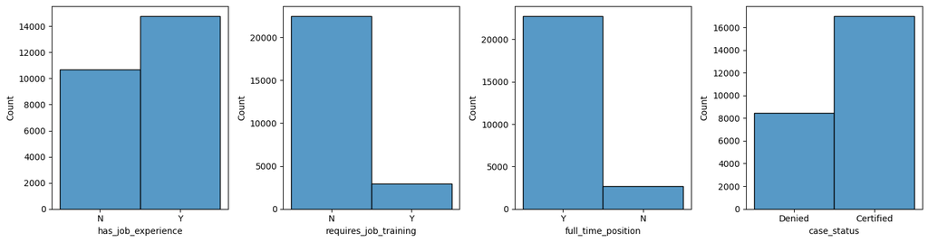

```python
# Defining the plotsize
plt.figure(figsize = (15, 4))

#extract numberical features that has only binary result
number_features = ['has_job_experience', 'requires_job_training',
                   'full_time_position', 'case_status']

# Plotting histogram
for i, feature in enumerate(number_features):
  plt.subplot(1,4,i+1)  #assign a subplot in the main plot
  sns.histplot(data[feature]) #plot the histogram

plt.tight_layout() # to add spacing between plots
plt.show() # to display the plot
```

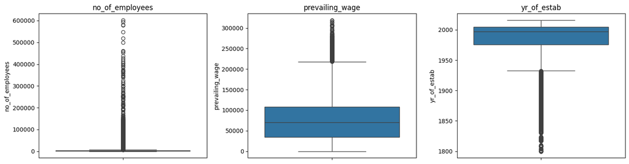

```python
#number of employees, prevailing wages, year of establishment are all heavily skewed.
# Let us draw their graph separately
# Defining the plotsize
plt.figure(figsize = (20, 4))
number_features = ['no_of_employees', 'prevailing_wage', 'yr_of_estab']

for i, feature in enumerate(number_features):
  plt.subplot(1,4,i+1)   # assigning a subplot to the main plot
  plt.title(feature)
  sns.boxplot(df[feature]) # plotting boxplot

plt.tight_layout() # to add spacing between plots
plt.show() # to display the plot
```

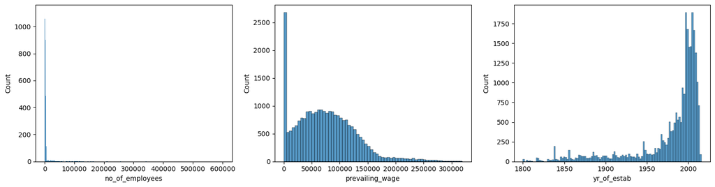

```python
#number of employees, prevailing wages, year of establishment are all heavily skewed.
# Let us draw their graph separately
# Defining the plotsize
plt.figure(figsize = (20, 4))
number_features = ['no_of_employees', 'prevailing_wage', 'yr_of_estab']
# Plotting histogram
for i, feature in enumerate(number_features):
  plt.subplot(1,4,i+1)  #assign a subplot in the main plot
  sns.histplot(df[feature]) #plot the histogram

plt.tight_layout() # to add spacing between plots
plt.show() # to display the plot
```

```
Index(['continent', 'education_of_employee', 'region_of_employment',
       'unit_of_wage'],
      dtype='object')
```

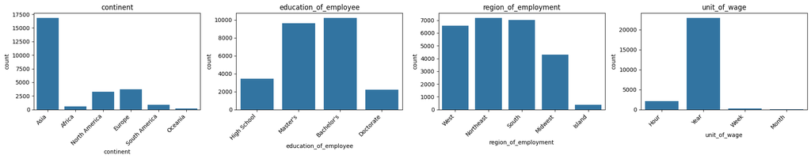

```python
# Defining the plotsize
plt.figure(figsize = (20, 4)) # Adjusted figsize for a single row

categorical_features = df.select_dtypes(include = ['category']).columns #for selecting categorical dataytpes from all features
print(categorical_features)
for i, feature in enumerate(categorical_features):
  plt.subplot(1,4,i+1)   # assigning a subplot to the main plot, adjusted for a single row (1 row, 4 columns)
  plt.title(feature)
  sns.countplot(x=data[feature]) # plotting countplot with categories on x-axis (default)
  plt.xticks(rotation=45, ha='right') # Rotate x-axis labels for better readability

plt.tight_layout() # add spacing between plots
plt.show() # to show the plot
```

## Bivariant Analysis:

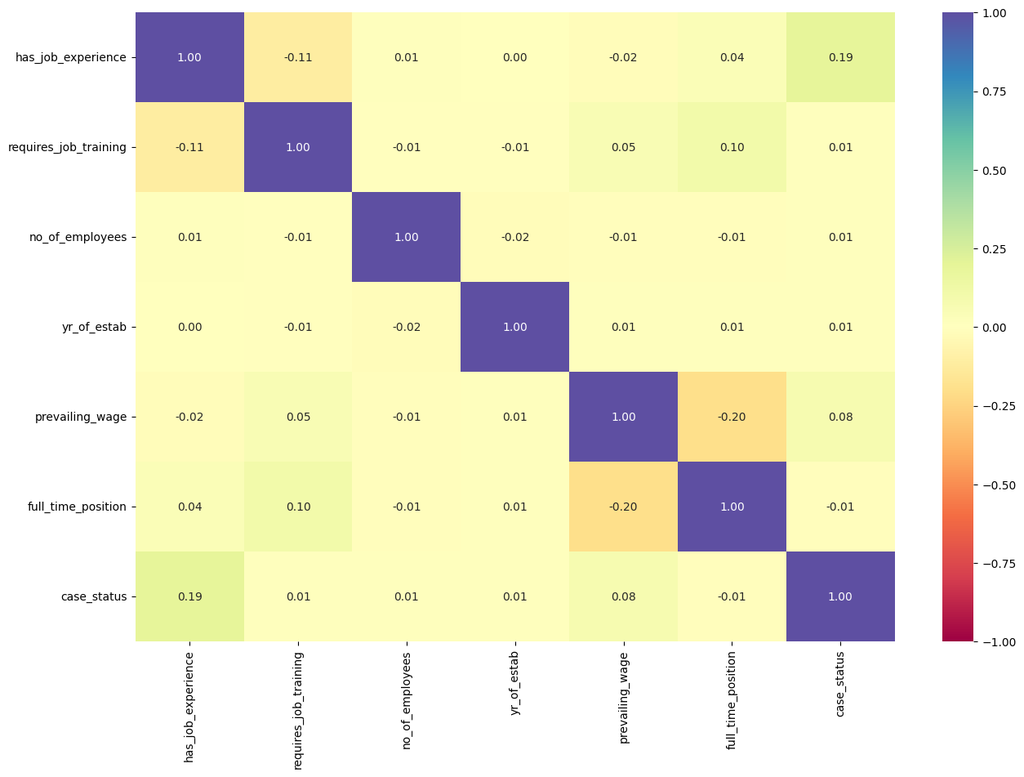

```python
# Let us further check the correleation between variables using heatmap.
plt.figure(figsize = (15,10))

#select only numeric columns before calculating correlation
numeric_features = df.select_dtypes(include = ['float64', 'int64']).columns

#plot the heatmap
sns.heatmap(df[numeric_features].corr(), annot = True, vmin =-1, vmax=1, fmt=".2f", cmap="Spectral")
plt.show()
```

## Correlation with Case_status(target) feature

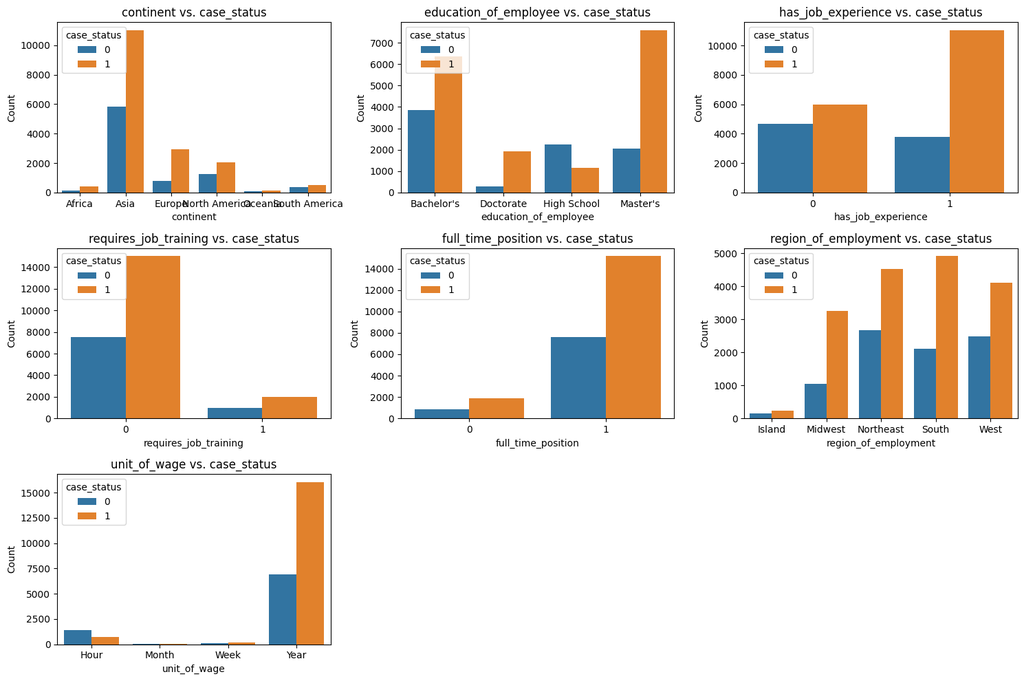

```python
# Define the list of categorical features to analyze against 'case_status'
cols_for_bivariate = ['continent', 'education_of_employee', 'has_job_experience', 'requires_job_training', 'full_time_position', 'region_of_employment', 'unit_of_wage']

# Plot count plots for each categorical feature against 'case_status'
plt.figure(figsize=(15, 10)) # Define the size of the figure

for i, col in enumerate(cols_for_bivariate):
    plt.subplot(3, 3, i + 1) # Assign a subplot in the main plot
    sns.countplot(data=df, x=col, hue='case_status') # Create a count plot, split by 'case_status'
    plt.title(f'{col} vs. case_status') # Add a title to the subplot
    plt.xlabel(col) # Set the x-axis label
    plt.ylabel('Count') # Set the y-axis label
    plt.legend(title='case_status', loc='upper left') # Add a legend

plt.tight_layout() # Adjust layout to prevent overlapping
plt.show() # Display the plot
```

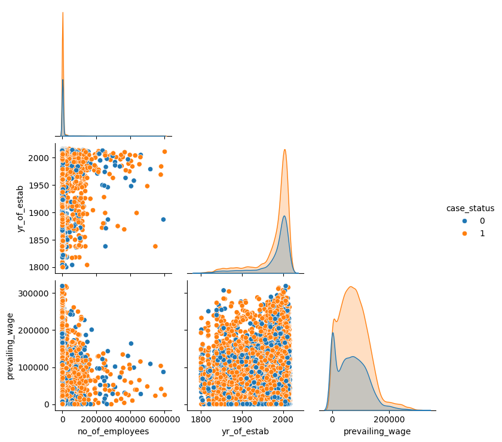

```python
# we shall plot pair plot against the target variable case_status.
# This helps visualize relation between numerical varaibles and case_status

plt.figure(figsize=(18,10))
# Removed binary integer columns from corr_vars as pairplot with kde is not suitable for them
corr_vars = ['no_of_employees', 'yr_of_estab', 'prevailing_wage'] # numerical values to get correlation details

sns.pairplot(data = df, vars =corr_vars , hue = 'case_status', diag_kind='kde', corner = True)  # gives pairplot. This is used to get relationship between multiple features.
plt.show(); # to display plot
```

```python
# Select categorical columns
categorical_cols = df.select_dtypes(include=['category']).columns

# Apply one-hot encoding
df_encoded = pd.get_dummies(df, columns=categorical_cols, drop_first=True)

# Display the first few rows of the encoded DataFrame
display(df_encoded.head())
```

|  | has_job_experience | requires_job_training | no_of_employees | yr_of_estab | prevailing_wage | full_time_position | case_status | continent_Asia | continent_Europe | continent_North America | continent_Oceania | continent_South America | education_of_employee_Doctorate | education_of_employee_High School | education_of_employee_Master's | region_of_employment_Midwest | region_of_employment_Northeast | region_of_employment_South | region_of_employment_West | unit_of_wage_Month | unit_of_wage_Week | unit_of_wage_Year |
| --- | --- | --- | --- | --- | --- | --- | --- | --- | --- | --- | --- | --- | --- | --- | --- | --- | --- | --- | --- | --- | --- | --- |
| 0 | 0 | 0 | 14513 | 2007 | 592.203 | 1 | 0 | True | False | False | False | False | False | True | False | False | False | False | True | False | False | False |
| 1 | 1 | 0 | 2412 | 2002 | 83425.650 | 1 | 1 | True | False | False | False | False | False | False | True | False | True | False | False | False | False | True |
| 2 | 0 | 1 | 44444 | 2008 | 122996.860 | 1 | 0 | True | False | False | False | False | False | False | False | False | False | False | True | False | False | True |
| 3 | 0 | 0 | 98 | 1897 | 83434.030 | 1 | 0 | True | False | False | False | False | False | False | False | False | False | False | True | False | False | True |
| 4 | 1 | 0 | 1082 | 2005 | 149907.390 | 1 | 1 | False | False | False | False | False | False | False | True | False | False | True | False | False | False | True |

```python
# check the shape of data after one-hot encoding
df_encoded.shape
```

```
(25480, 22)
```

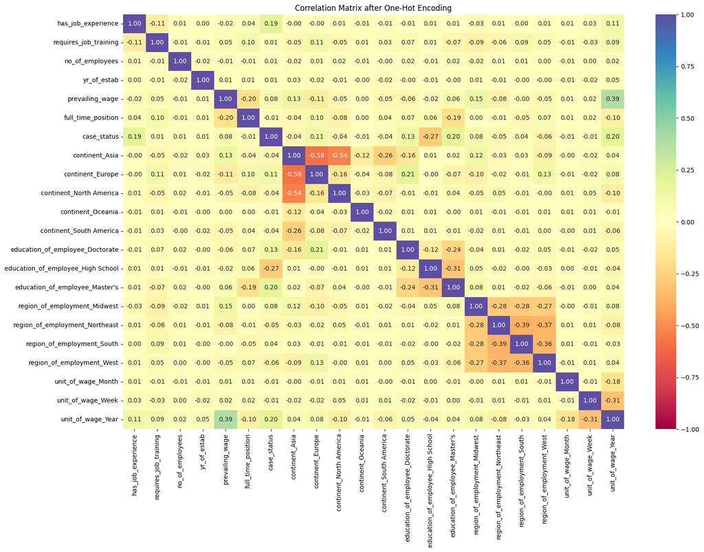

```python
# Calculate the correlation matrix
correlation_matrix = df_encoded.corr()

# Plot the heatmap
plt.figure(figsize=(18, 12))
sns.heatmap(correlation_matrix, annot = True, vmin =-1, vmax=1, fmt=".2f", cmap="Spectral")  #heapmap after onehot-encoding
plt.title('Correlation Matrix after One-Hot Encoding')
plt.show()
```

## Feature Engineering

- We have already treated number_of_employees for negative values.
- We still see a huge range of values for yr_of_establishment, prevailing_wage and no_of_employees.

```python
# check the count per each unique year.
print(df['yr_of_estab'].value_counts())
```

```
yr_of_estab
1998    1134
2005    1051
2001    1017
2007     994
1999     870
        ...
1820       6
1846       4
1822       4
1810       3
1824       2
Name: count, Length: 199, dtype: int64
```

- We see a large range of values for yr_of_estab column.
- We will split all the data into 3 categories so that it can be easily processed.

```python
# categorizising the yr_of_estab into 3 categories
df["establishment_period"] = pd.qcut(
    df["yr_of_estab"],
    q=[0, 0.25, 0.5, 1], # Using approximate quantiles for 3 bins
    labels=["Old", "Mid", "New"] #label the categories as Old, Mid, New
)
print(df['establishment_period'].value_counts()) #check the number of values in each category
```

```
establishment_period
New    12473
Mid     6535
Old     6472
Name: count, dtype: int64
```

- Similary for no_of_employees features, we fit all the feature data of no_of_employees into 5 buckets
- We are dividing employees in the establishment into 5 categories as below.

```python
# Define the bin edges for no_of_employees
employee_bins = [0, 100, 1000, 10000, 100000, df['no_of_employees'].max()]

# Define the labels for the bins
employee_labels = ["micro_scale", "mini_scale", "small_scale", "mid_scale", "large_scale"]

# Categorize no_of_employees into bins
df["establishment_type"] = pd.cut(
    df["no_of_employees"],
    bins=employee_bins,
    labels=employee_labels,
    right=True, # Include the right edge of the bin
    include_lowest=True # Include the lowest value in the first bin
)

# Print the value counts of the new categorical column
print(df['establishment_type'].value_counts())
```

```
establishment_type
small_scale    17803
mini_scale      5675
mid_scale       1165
micro_scale      566
large_scale      271
Name: count, dtype: int64
```

```python
# now convert prevailing_wage into same unit as yearly wage.
# Conversion dictionary
wage_multiplier = {
    "Hour": 2080,    # assuming 40 hours/week * 52 weeks
    "Week": 52,      # no of weeks per year
    "Bi-Weekly": 26, # no of bi-Weeklys in an year
    "Month": 12,     # no of months in an year
    "Year": 1        # years
}

# Convert wages to yearly
df['yearly_wage'] = df.apply(lambda x: x['prevailing_wage'] * wage_multiplier.get(x['unit_of_wage'], 1), axis=1)
df.head() #check the head after adding new columns.
```

|  | continent | education_of_employee | has_job_experience | requires_job_training | no_of_employees | yr_of_estab | region_of_employment | prevailing_wage | unit_of_wage | full_time_position | case_status | establishment_period | establishment_type | yearly_wage |
| --- | --- | --- | --- | --- | --- | --- | --- | --- | --- | --- | --- | --- | --- | --- |
| 0 | Asia | High School | 0 | 0 | 14513 | 2007 | West | 592.203 | Hour | 1 | 0 | New | mid_scale | 1231782.032 |
| 1 | Asia | Master's | 1 | 0 | 2412 | 2002 | Northeast | 83425.650 | Year | 1 | 1 | New | small_scale | 83425.650 |
| 2 | Asia | Bachelor's | 0 | 1 | 44444 | 2008 | West | 122996.860 | Year | 1 | 0 | New | mid_scale | 122996.860 |
| 3 | Asia | Bachelor's | 0 | 0 | 98 | 1897 | West | 83434.030 | Year | 1 | 0 | Old | micro_scale | 83434.030 |
| 4 | Africa | Master's | 1 | 0 | 1082 | 2005 | South | 149907.390 | Year | 1 | 1 | New | small_scale | 149907.390 |

```python
# check the shape of df after modification.
df.shape
```

```
(25480, 14)
```

## checking for null values

```python
# Check for null values
df.isnull().sum()
```

|  | 0 |
| --- | --- |
| continent | 0 |
| education_of_employee | 0 |
| has_job_experience | 0 |
| requires_job_training | 0 |
| no_of_employees | 0 |
| yr_of_estab | 0 |
| region_of_employment | 0 |
| prevailing_wage | 0 |
| unit_of_wage | 0 |
| full_time_position | 0 |
| case_status | 0 |
| establishment_period | 0 |
| establishment_type | 0 |
| yearly_wage | 0 |

**dtype:** int64

- There are no missing values.
- We shall create a copy of the data and drop the treated features

```python
# creating a copy of data
data_bkp = df.copy()

#Now drop the yr_of_estab, no_of_employees, Prevailing_wage, unit_of_wage columns
df.drop(['yr_of_estab', 'no_of_employees', 'prevailing_wage', 'unit_of_wage'], axis=1, inplace=True)

#check the datatypes of remaining ones
df.info()
```

```
<class 'pandas.core.frame.DataFrame'>
RangeIndex: 25480 entries, 0 to 25479
Data columns (total 10 columns):
 #   Column                 Non-Null Count  Dtype
---  ------                 --------------  -----
 0   continent              25480 non-null  category
 1   education_of_employee  25480 non-null  category
 2   has_job_experience     25480 non-null  int64
 3   requires_job_training  25480 non-null  int64
 4   region_of_employment   25480 non-null  category
 5   full_time_position     25480 non-null  int64
 6   case_status            25480 non-null  int64
 7   establishment_period   25480 non-null  category
 8   establishment_type     25480 non-null  category
 9   yearly_wage            25480 non-null  float64
dtypes: category(5), float64(1), int64(4)
memory usage: 1.1 MB
```

## Data Preparation for Modeling

```python
X = df.drop(["case_status"], axis=1) #drop the target feature on X axis

# Label certified as 1 and 0 otherwise
y = df["case_status"].apply(lambda x: 1 if x == "certified" else 0)
```

```python
# We are splitting the data before encoding to avoid any possible data leakage.

# Define X and y using the already processed df DataFrame
X = df.drop(["case_status"], axis=1) #drop the target feature on X axis

# Use the already integer-encoded case_status column as the target
y = df["case_status"]

# Splitting data into training, validation and test set:
# first we split data into 2 parts, say temporary and test
X_temp, X_test, y_temp, y_test = train_test_split(
    X, y, test_size=0.2, random_state=1, stratify=y
)

# then we split the temporary set into train and validation
X_train, X_val, y_train, y_val = train_test_split(
    X_temp, y_temp, test_size=0.25, random_state=1, stratify=y_temp
)

print(X_train.info())
print('-' * 80)
print(X_train.shape, X_val.shape, X_test.shape)
```

```
<class 'pandas.core.frame.DataFrame'>
Index: 15288 entries, 5008 to 21791
Data columns (total 9 columns):
 #   Column                 Non-Null Count  Dtype
---  ------                 --------------  -----
 0   continent              15288 non-null  category
 1   education_of_employee  15288 non-null  category
 2   has_job_experience     15288 non-null  int64
 3   requires_job_training  15288 non-null  int64
 4   region_of_employment   15288 non-null  category
 5   full_time_position     15288 non-null  int64
 6   establishment_period   15288 non-null  category
 7   establishment_type     15288 non-null  category
 8   yearly_wage            15288 non-null  float64
dtypes: category(5), float64(1), int64(3)
memory usage: 672.8 KB
None
--------------------------------------------------------------------------------
(15288, 9) (5096, 9) (5096, 9)
```

```python
# We need to encode the categorical values in our train, validation and test data

cat_cols = X_train.select_dtypes(include='category').columns
le_dict = {}

for col in cat_cols:
  #calling LabelEncoder
  le = LabelEncoder()

  # Train on training set
  X_train[col] = le.fit_transform(X_train[col])

  # Apply same mapping on validation set
  X_val[col] = le.transform(X_val[col])

  # Apply same mapping on test set
  X_test[col] = le.transform(X_test[col])
  le_dict[col] = le
```

```python
print("Number of rows in train data =", X_train.shape[0])
print("Number of rows in validation data =", X_val.shape[0])
print("Number of rows in test data =", X_test.shape[0])
```

```
Number of rows in train data = 15288
Number of rows in validation data = 5096
Number of rows in test data = 5096
```

## Model Building

### Model evaluation criteria

**Model can make wrong predictions as:**

- The model can predict an applicant as certified when actually the application is denied.
- The model can predict as Denied for a Certified application.

**Which case is more important?**

- Predicting a false positive(model predicts as approved. but applicantion is denied) result in wastage of resources.
- Predicting a false negative (model predicted Denied but application is Certified) causes miss of oppurtunity for a potential applicant as well as company.

**How to reduce this loss**

- This loss can be reduced with increased F1 score.

**Let's define a function to output different metrics (including recall) on the train and test set and a function to show confusion matrix so that we do not have to use the same code repetitively while evaluating models.**

```python
# defining a function to compute different metrics to check performance of a classification model built using sklearn
def model_performance_classification_sklearn(model, predictors, target):
    """
    Function to compute different metrics to check classification model performance

    model: classifier
    predictors: independent variables
    target: dependent variable
    """

    # predicting using the independent variables
    pred = model.predict(predictors)

    acc = accuracy_score(target, pred)  # to compute Accuracy
    recall = recall_score(target, pred)  # to compute Recall
    precision = precision_score(target, pred)  # to compute Precision
    f1 = f1_score(target, pred)  # to compute F1-score

    # creating a dataframe of metrics
    df_perf = pd.DataFrame(
        {"Accuracy": acc, "Recall": recall, "Precision": precision, "F1": f1,},
        index=[0],
    )

    return df_perf #returning performance of the model.
```

## Initial Model Building

### Model Building - Original Data

```python
models = []  # Empty list to store all the models

# Append DecisionTreeClassifier to model with random_state set and specified as balanced(this gives more weightage for minority class)
models.append(("dtree", DecisionTreeClassifier(random_state=1, class_weight='balanced')))

# Append Random forest Classifier to model
models.append(("Random forest", RandomForestClassifier(n_estimators=100, random_state=1, class_weight='balanced')))

# Append BaggingClassifier  Classifier to model
models.append(("Bagging", BaggingClassifier(estimator=DecisionTreeClassifier(random_state=1, class_weight='balanced'), random_state=1)))

# Append GradientBoosting Classifier to model
models.append(("GBM", GradientBoostingClassifier(n_estimators=100, random_state=1)))

# Append AdaBoostClassifier to model
models.append(("Adaboost", AdaBoostClassifier(n_estimators=100, random_state=1)))

print("\nTraining Performance:\n")
for name, model in models:
    model.fit(X_train, y_train) # Fitting model on X_train and y_train
    scores = f1_score(y_train, model.predict(X_train)) # Getting F1 score on train data
    print("{}: {:.3f}".format(name, scores)) # Print the scores with 2 decimal places

print('-' * 80)

print("\nValidation Performance:\n")
for name, model in models:
    model.fit(X_train, y_train) #Fitting on model on train data
    scores_val = f1_score(y_val, model.predict(X_val)) #F1 score for validation data
    print("{}: {:.3f}".format(name, scores_val)) # Print the scores with 2 decimal places
```

```
Training Performance:

dtree: 1.000
Random forest: 1.000
Bagging: 0.983
GBM: 0.826
Adaboost: 0.816
--------------------------------------------------------------------------------

Validation Performance:

dtree: 0.744
Random forest: 0.766
Bagging: 0.764
GBM: 0.822
Adaboost: 0.815
```

```python
print("\nTraining and Validation Performance Difference:\n")

for name, model in models:
    model.fit(X_train, y_train) # Fit the model ontrain data
    scores_train = f1_score(y_train, model.predict(X_train)) # Get f1 score on train data
    scores_val = f1_score(y_val, model.predict(X_val)) # Get f1 score on validation data
    difference = scores_train - scores_val # Get difference between train and validation metrics
    print("{}:        Training Score: {:.3f},      Validation Score: {:.4f},       Difference: {:.4f}".format(name, scores_train, scores_val, difference))
```

```
Training and Validation Performance Difference:

dtree:        Training Score: 1.000,      Validation Score: 0.7439,       Difference: 0.2561
Random forest:        Training Score: 1.000,      Validation Score: 0.7663,       Difference: 0.2337
Bagging:        Training Score: 0.983,      Validation Score: 0.7638,       Difference: 0.2196
GBM:        Training Score: 0.826,      Validation Score: 0.8218,       Difference: 0.0040
Adaboost:        Training Score: 0.816,      Validation Score: 0.8152,       Difference: 0.0008
```

## Oversampling

As the given data set is kind of imbalance data, we may get beter predictions if we over sample the data

```python
print("Before Oversampling, counts of label 'Denied': {} \n".format(sum(y_train == 0)))

sm = SMOTE(
    sampling_strategy=1, k_neighbors=5, random_state=1
)  # Synthetic Minority Over Sampling Technique for over sampling

# resample train data with over sampling
X_train_over, y_train_over = sm.fit_resample(X_train, y_train)


print("After Oversampling, counts of label 'Certified': {}".format(sum(y_train_over == 1)))
print("After Oversampling, counts of label 'Denied': {} \n".format(sum(y_train_over == 0)))


print("After Oversampling, the shape of train_X: {}".format(X_train_over.shape))
print("After Oversampling, the shape of train_y: {} \n".format(y_train_over.shape))
```

```
Before Oversampling, counts of label 'Denied': 5078

After Oversampling, counts of label 'Certified': 10210
After Oversampling, counts of label 'Denied': 10210

After Oversampling, the shape of train_X: (20420, 9)
After Oversampling, the shape of train_y: (20420,)
```

```python
models = []  # Empty list to store all the models

# Appending models into the list
models.append(("dtree", DecisionTreeClassifier(random_state=1, class_weight='balanced')))
models.append(("Random forest", RandomForestClassifier(random_state=1, class_weight='balanced')))
models.append(("Bagging", BaggingClassifier(estimator=DecisionTreeClassifier(random_state=1, class_weight='balanced'), random_state=1)))
models.append(("GBM", GradientBoostingClassifier(random_state=1)))
models.append(("Adaboost", AdaBoostClassifier(random_state=1)))

print("\n" "Training Performance:" "\n")
for name, model in models:
    model.fit(X_train_over, y_train_over) #fitting train data into model
    scores = f1_score(y_train_over, model.predict(X_train_over)) #get f1_score on training oversampled data
    print("{}: {:.3f}".format(name, scores)) # print scores

print('-' * 80)

print("\n" "Validation Performance:" "\n")

for name, model in models:
    model.fit(X_train_over, y_train_over) # Fitting Overfitting data to model
    scores = f1_score(y_val, model.predict(X_val)) #getting f1_Score on validation data
    print("{}: {:.3f}".format(name, scores)) #print scores
```

```
Training Performance:

dtree: 1.000
Random forest: 1.000
Bagging: 0.978
GBM: 0.755
Adaboost: 0.727
--------------------------------------------------------------------------------

Validation Performance:

dtree: 0.717
Random forest: 0.733
Bagging: 0.730
GBM: 0.778
Adaboost: 0.749
```

```python
print("\nTraining and Validation Performance Difference:\n")

for name, model in models:
    model.fit(X_train_over, y_train_over) # Fit the model ontrain data
    scores_train = f1_score(y_train_over, model.predict(X_train_over)) # Get f1 score on train data
    scores_val = f1_score(y_val, model.predict(X_val)) # Get f1 score on validation data
    difference = scores_train - scores_val # Get difference between train and validation metrics
    print("{}:        Training Score: {:.3f},      Validation Score: {:.4f},       Difference: {:.4f}".format(name, scores_train, scores_val, difference))
```

```
Training and Validation Performance Difference:

dtree:        Training Score: 1.000,      Validation Score: 0.7174,       Difference: 0.2826
Random forest:        Training Score: 1.000,      Validation Score: 0.7333,       Difference: 0.2665
Bagging:        Training Score: 0.978,      Validation Score: 0.7299,       Difference: 0.2483
GBM:        Training Score: 0.755,      Validation Score: 0.7775,       Difference: -0.0229
Adaboost:        Training Score: 0.727,      Validation Score: 0.7494,       Difference: -0.0228
```

## Model Building - Undersampled Data

```python
rus = RandomUnderSampler(random_state=1)  #using RandomUndersampler to undersample
X_train_un, y_train_un = rus.fit_resample(X_train, y_train) #creating undersample_train data
```

```python
# Check the data before and after Sampling
print("Before Under Sampling, counts of label 'Yes': {}".format(sum(y_train == 1)))
print("Before Under Sampling, counts of label 'No': {} \n".format(sum(y_train == 0)))

print("After Under Sampling, counts of label 'Yes': {}".format(sum(y_train_un == 1)))
print("After Under Sampling, counts of label 'No': {} \n".format(sum(y_train_un == 0)))

print("After Under Sampling, the shape of train_X: {}".format(X_train_un.shape))
print("After Under Sampling, the shape of train_y: {} \n".format(y_train_un.shape))
```

```
Before Under Sampling, counts of label 'Yes': 10210
Before Under Sampling, counts of label 'No': 5078

After Under Sampling, counts of label 'Yes': 5078
After Under Sampling, counts of label 'No': 5078

After Under Sampling, the shape of train_X: (10156, 9)
After Under Sampling, the shape of train_y: (10156,)
```

```python
models = []  # Empty list to store all the models

# Appending models into the list
models.append(("dtree", DecisionTreeClassifier(random_state=1, class_weight='balanced')))
models.append(("Random forest", RandomForestClassifier(random_state=1, class_weight='balanced')))
models.append(("Bagging", BaggingClassifier(estimator=DecisionTreeClassifier(random_state=1, class_weight='balanced'), random_state=1)))
models.append(("GBM", GradientBoostingClassifier(random_state=1)))
models.append(("Adaboost", AdaBoostClassifier(random_state=1)))

# Extracting performance numbers on undersample train data
print("\n" "Training Performance:" "\n")
for name, model in models:
    model.fit(X_train_un, y_train_un)
    scores = f1_score(y_train_un, model.predict(X_train_un))
    print("{}: {:.3f}".format(name, scores))
print('-' * 80)

print("\n" "Validation Performance:" "\n")
# Getting f1_score for validation data
for name, model in models:
    model.fit(X_train_un, y_train_un)
    scores = f1_score(y_val, model.predict(X_val))
    print("{}: {:.3f}".format(name, scores))
```

```
Training Performance:

dtree: 1.000
Random forest: 1.000
Bagging: 0.976
GBM: 0.722
Adaboost: 0.705
--------------------------------------------------------------------------------

Validation Performance:

dtree: 0.688
Random forest: 0.717
Bagging: 0.686
GBM: 0.769
Adaboost: 0.773
```

```python
print("\nTraining and Validation Performance Difference:\n")
# To get difference of f1_score on both test and train data
for name, model in models:
    model.fit(X_train_un, y_train_un)
    scores_train = f1_score(y_train_un, model.predict(X_train_un))
    scores_val = f1_score(y_val, model.predict(X_val))
    difference3 = scores_train - scores_val
    print("{}: Training Score: {:.4f}, Validation Score: {:.4f}, Difference: {:.4f}".format(name, scores_train, scores_val, difference3))
```

```
Training and Validation Performance Difference:

dtree: Training Score: 1.0000, Validation Score: 0.6882, Difference: 0.3118
Random forest: Training Score: 0.9999, Validation Score: 0.7166, Difference: 0.2833
Bagging: Training Score: 0.9761, Validation Score: 0.6864, Difference: 0.2897
GBM: Training Score: 0.7222, Validation Score: 0.7689, Difference: -0.0467
Adaboost: Training Score: 0.7053, Validation Score: 0.7727, Difference: -0.0674
```

## Tuning AdaBoostClassifier model with Undersampled data

```python
# defining model
Model = AdaBoostClassifier(random_state=1)

# Parameter grid to pass in RandomSearchCV
param_grid = {
    "n_estimators": np.arange(10, 100, 10),
    "learning_rate": [0.1, 0.01, 0.2, 0.05, 1],
    "estimator": [
        DecisionTreeClassifier(max_depth=5, random_state=1),
        DecisionTreeClassifier(max_depth=7, random_state=1),
        DecisionTreeClassifier(max_depth=9, random_state=1),
    ],
}

# Type of scoring used to compare parameter combinations
scorer = metrics.make_scorer(metrics.f1_score)

#Calling RandomizedSearchCV
randomized_cv = RandomizedSearchCV(estimator=Model, param_distributions=param_grid, n_jobs = -1, n_iter=50, scoring=scorer, cv=5, random_state=1)

#Calling RandomizedSearchCV on under sampled data
randomized_cv.fit(X_train_un, y_train_un)

print("Best parameters are {} with CV score={}:" .format(randomized_cv.best_params_,randomized_cv.best_score_))
```

```
Best parameters are {'n_estimators': np.int64(50), 'learning_rate': 0.1, 'estimator': DecisionTreeClassifier(max_depth=5, random_state=1)} with CV score=0.7089255397645045:
```

```python
# configuring the best parameters
tuned_adb1 = AdaBoostClassifier(
    random_state=1,
    n_estimators=50,
    learning_rate=0.1,
    estimator=DecisionTreeClassifier(max_depth=5, random_state=1),
)
tuned_adb1.fit(X_train_un, y_train_un)
```

```
AdaBoostClassifier(estimator=DecisionTreeClassifier(max_depth=5,
                                                    random_state=1),
                   learning_rate=0.1, random_state=1)
```

```python
# Checking model's performance on training set
adb_train1 = model_performance_classification_sklearn(tuned_adb1, X_train_un, y_train_un)
adb_train1
```

|  | Accuracy | Recall | Precision | F1 |
| --- | --- | --- | --- | --- |
| 0 | 0.706 | 0.722 | 0.700 | 0.711 |

```python
# Checking model's performance on validation set
adb_val1 = model_performance_classification_sklearn(tuned_adb1, X_val, y_val)
adb_val1
```

|  | Accuracy | Recall | Precision | F1 |
| --- | --- | --- | --- | --- |
| 0 | 0.710 | 0.718 | 0.825 | 0.768 |

## Tuning Gradient Boosting model with Undersampled Data

```python
#Creating pipeline
Model = GradientBoostingClassifier(random_state=1)

#Parameter grid to pass in RandomSearchCV
param_grid = {
    "init": [AdaBoostClassifier(random_state=1),DecisionTreeClassifier(random_state=1)],
    "n_estimators": np.arange(125,175,25),
    "learning_rate": [0.01, 0.2, 0.05, 1],
    "subsample":[0.8,0.9,1],
    "max_features":[0.5,0.7,1],
}

# Type of scoring used to compare parameter combinations
scorer = metrics.make_scorer(metrics.f1_score)

#Calling RandomizedSearchCV
randomized_cv = RandomizedSearchCV(estimator=Model, param_distributions=param_grid, n_iter=50, scoring=scorer, cv=5, random_state=1, n_jobs = -1)

#Fitting parameters in RandomizedSearchCV
randomized_cv.fit(X_train_un,y_train_un)

print("Best parameters are {} with CV score={}:" .format(randomized_cv.best_params_,randomized_cv.best_score_))
```

```
Best parameters are {'subsample': 1, 'n_estimators': np.int64(125), 'max_features': 0.7, 'learning_rate': 0.05, 'init': AdaBoostClassifier(random_state=1)} with CV score=0.7105906991647967:
```

```python
tuned_gbm1 = GradientBoostingClassifier(
    random_state=1,
    subsample=1,
    n_estimators=125,
    max_features=0.7,
    learning_rate=0.05,
    init=AdaBoostClassifier(random_state=1),
)
tuned_gbm1.fit(X_train_un, y_train_un)
```

```
GradientBoostingClassifier(init=AdaBoostClassifier(random_state=1),
                           learning_rate=0.05, max_features=0.7,
                           n_estimators=125, random_state=1, subsample=1)
```

```python
# Checking model's performance on training set
gbm1_train = model_performance_classification_sklearn(
    tuned_gbm1, X_train_un, y_train_un
)
gbm1_train
```

|  | Accuracy | Recall | Precision | F1 |
| --- | --- | --- | --- | --- |
| 0 | 0.712 | 0.741 | 0.701 | 0.720 |

```python
# Checking model's performance on validation set
gbm1_val = model_performance_classification_sklearn(tuned_gbm1, X_val, y_val)
gbm1_val
```

|  | Accuracy | Recall | Precision | F1 |
| --- | --- | --- | --- | --- |
| 0 | 0.716 | 0.732 | 0.823 | 0.775 |

## Tuning AdaBoost model with Oversampled data

```python
# defining model
Model = AdaBoostClassifier(random_state=1)

# Parameter grid to pass in RandomSearchCV
param_grid = {
    "n_estimators": np.arange(10, 100, 10),
    "learning_rate": [0.1, 0.01, 0.2, 0.05, 1],
    "estimator": [
        DecisionTreeClassifier(max_depth=5, random_state=1),
        DecisionTreeClassifier(max_depth=7, random_state=1),
        DecisionTreeClassifier(max_depth=9, random_state=1),
    ],
}

# Type of scoring used to compare parameter combinations
scorer = metrics.make_scorer(metrics.f1_score)

#Calling RandomizedSearchCV
randomized_cv = RandomizedSearchCV(estimator=Model, param_distributions=param_grid, n_jobs = -1, n_iter=50, scoring=scorer, cv=5, random_state=1)

#Fitting parameters in RandomizedSearchCV
randomized_cv.fit(X_train_over, y_train_over)

print("Best parameters are {} with CV score={}:" .format(randomized_cv.best_params_,randomized_cv.best_score_))
```

```
Best parameters are {'n_estimators': np.int64(40), 'learning_rate': 0.1, 'estimator': DecisionTreeClassifier(max_depth=7, random_state=1)} with CV score=0.7495476860096357:
```

```python
tuned_adb_over = AdaBoostClassifier(
    random_state=1,
    n_estimators=40,
    learning_rate=0.1,
    estimator=DecisionTreeClassifier(max_depth=7, random_state=1),
)
tuned_adb_over.fit(X_train_over, y_train_over)
```

```
AdaBoostClassifier(estimator=DecisionTreeClassifier(max_depth=7,
                                                    random_state=1),
                   learning_rate=0.1, n_estimators=40, random_state=1)
```

```python
# Checking model's performance on training set
adb_train2 = model_performance_classification_sklearn(tuned_adb_over, X_train_over, y_train_over)
adb_train2
```

|  | Accuracy | Recall | Precision | F1 |
| --- | --- | --- | --- | --- |
| 0 | 0.766 | 0.774 | 0.762 | 0.768 |

```python
# Checking model's performance on validation set
adb_val2 = model_performance_classification_sklearn(tuned_adb_over, X_val, y_val)
adb_val2
```

|  | Accuracy | Recall | Precision | F1 |
| --- | --- | --- | --- | --- |
| 0 | 0.708 | 0.754 | 0.797 | 0.775 |

## Tuning GBM with over sampled data

```python
#Creating pipeline
Model = GradientBoostingClassifier(random_state=1)

#Parameter grid to pass in RandomSearchCV
param_grid = {
    "init": [AdaBoostClassifier(random_state=1),DecisionTreeClassifier(random_state=1)],
    "n_estimators": np.arange(125,175,25),
    "learning_rate": [0.01, 0.2, 0.05, 1],
    "subsample":[0.8,0.9,1],
    "max_features":[0.5,0.7,1],
}

# Type of scoring used to compare parameter combinations
scorer = metrics.make_scorer(metrics.f1_score)

#Calling RandomizedSearchCV
randomized_cv = RandomizedSearchCV(estimator=Model, param_distributions=param_grid, n_iter=50, scoring=scorer, cv=5, random_state=1, n_jobs = -1)

#Fitting parameters in RandomizedSearchCV
randomized_cv.fit(X_train_over,y_train_over)

print("Best parameters are {} with CV score={}:" .format(randomized_cv.best_params_,randomized_cv.best_score_))
```

```
Best parameters are {'subsample': 0.9, 'n_estimators': np.int64(150), 'max_features': 0.7, 'learning_rate': 0.2, 'init': AdaBoostClassifier(random_state=1)} with CV score=0.7474804654342829:
```

```python
tuned_gbm2 = GradientBoostingClassifier(
    random_state=1,
    subsample=0.9,
    n_estimators=150,
    max_features=0.7,
    learning_rate=0.2,
    init=AdaBoostClassifier(random_state=1),
)
tuned_gbm2.fit(X_train_over, y_train_over)
```

```
GradientBoostingClassifier(init=AdaBoostClassifier(random_state=1),
                           learning_rate=0.2, max_features=0.7,
                           n_estimators=150, random_state=1, subsample=0.9)
```

```python
# Checking model's performance on training set
gbm2_train = model_performance_classification_sklearn(
    tuned_gbm2, X_train_over, y_train_over
)
gbm2_train
```

|  | Accuracy | Recall | Precision | F1 |
| --- | --- | --- | --- | --- |
| 0 | 0.766 | 0.776 | 0.761 | 0.768 |

```python
gbm2_val = model_performance_classification_sklearn(tuned_gbm2, X_val, y_val)
gbm2_val
```

|  | Accuracy | Recall | Precision | F1 |
| --- | --- | --- | --- | --- |
| 0 | 0.709 | 0.764 | 0.793 | 0.778 |

## **Model Comparison and Final Model Selection**

```python
# training performance comparison

models_train_comp_df = pd.concat(
    [
        gbm1_train.T,
        gbm2_train.T,
        adb_train1.T,
        adb_train2.T,
    ],
    axis=1,
)
models_train_comp_df.columns = [
    "Gradient boosting trained with Undersampled data",
    "Gradient boosting trained with Oversampled data",
    "AdaBoost trained with Undersampled data",
    "AdaBoost trained with Oversampled data",
]
print("Training performance comparison:")
models_train_comp_df
```

```
Training performance comparison:
```

[output not shown]

```python
# Validation performance comparison

models_train_comp_df = pd.concat(
    [ gbm1_val.T, gbm2_val.T, adb_val1.T, adb_val2.T], axis=1,
)
models_train_comp_df.columns = [
    "Gradient boosting trained with Undersampled data",
    "Gradient boosting trained with Oversampled data",
    "AdaBoost trained with Undersampled data",
    "AdaBoost trained with Oversampled data",
]
print("Validation performance comparison:")
models_train_comp_df
```

```
Validation performance comparison:
```

|  | Gradient boosting trained with Undersampled data | Gradient boosting trained with Oversampled data | AdaBoost trained with Undersampled data | AdaBoost trained with Oversampled data |
| --- | --- | --- | --- | --- |
| Accuracy | 0.716 | 0.709 | 0.710 | 0.708 |
| Recall | 0.732 | 0.764 | 0.718 | 0.754 |
| Precision | 0.823 | 0.793 | 0.825 | 0.797 |
| F1 | 0.775 | 0.778 | 0.768 | 0.775 |

```python
# Let's check the performance on test set
ada_test = model_performance_classification_sklearn(tuned_adb_over, X_test, y_test)
ada_test
```

|  | Accuracy | Recall | Precision | F1 |
| --- | --- | --- | --- | --- |
| 0 | 0.699 | 0.760 | 0.783 | 0.771 |

- On test data, the AdaBoost oversampling results are mentioned above.
- We can see a decent performance od the model on test data. Around 77%
- This performance is in line with what we achieved with this model on the train and validation sets
- So, this is a generalized model
- The confidance score of this will be in the range of 72-82 percent
- This can still further be tuned for better performance.

## Feature importance

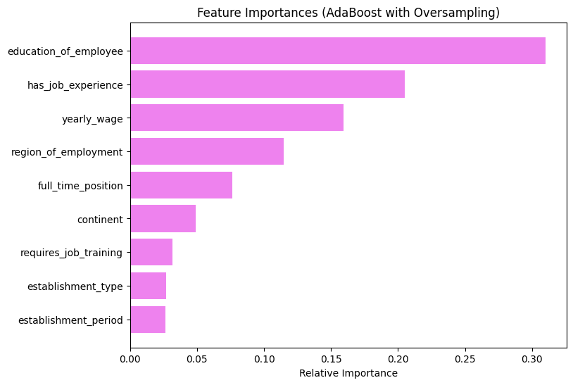

```python
# Get feature importances from the tuned AdaBoost model trained on oversampled data
importances = tuned_adb_over.feature_importances_

# Get the feature names from the training data
feature_names = X_train_over.columns

# Sort feature importances and get the corresponding indices
indices = np.argsort(importances)

# Plot the feature importances
plt.figure(figsize=(8, 6))
plt.title("Feature Importances (AdaBoost with Oversampling)")
plt.barh(range(len(indices)), importances[indices], color="violet", align="center")
plt.yticks(range(len(indices)), [feature_names[i] for i in indices])
plt.xlabel("Relative Importance")
plt.show()
```

- From feature importance graph, we see that education_of_employee is an important feature that majorly decides VISA approval.
- The next important feature are 'has_job_experience' and 'yearly_wage' followed by 'region_of_employment'

## Bussiness Insights and Recommendations

- Applicants with higher education are more likely to be certified. Education_of_employee is a key factor contributing for Visa Approval.
- Although eduaction_of_employee is key factor, not all applications with higher educationa are approved visa. Other factors like has_job_experience, yearly_wage, region_of_employement decide the actual appoval.
- As the number of final approvals will be fixed, it is advicable to first short list the Doctorate eduaction applicants.
- This also ensures that highly qualified applicatant will be processed and hence the chances of approval increases.
- Combination of educational qualification and has job experience can be used as indicators for approval in most of the cases.